# Data Science 6101 Project 2

### Exploratory Data Analysis

```r
# read in raw data
raw_wine_reviews.df <- read.csv("../data/wine_reviews.csv")

# prepare data
wine_reviews.df <- raw_wine_reviews.df %>%
  mutate(
    red = ifelse(color == "red", 1, 0),
    dom = ifelse(country == "US", 1, 0)
  ) %>%
    rename(
    fol = taster_following, name = taster_name,
    lat = comp_lat, lon = comp_lon, el = comp_el
  ) %>%
   bind_cols(as_tibble(model.matrix(~name + 0, . ))) %>%
  select(points, price, year, red, dom, fol, el, lat, lon, contains("name"),
    -name, -`nameAnne Krebiehl MW`, -name1) %>%
  mutate_all(as.numeric) %>%
  filter_all(function(x){!is.na(x)})

# xkable summary
wine_reviews.df %>%
  select(points, price, year, red, dom, fol, el, lat, lon) %>%
  cor() %>% xkablesummary(title = "Table 1")
```

Table 1

|  | points | price | year | red | dom | fol | el | lat | lon |
| --- | --- | --- | --- | --- | --- | --- | --- | --- | --- |
| Min | -0.044 | -0.062 | -0.133 | -0.133 | -0.740 | -0.028 | -0.199 | -0.247 | -0.740 |
| Q1 | 0.055 | -0.020 | -0.034 | -0.050 | 0.011 | 0.027 | -0.044 | -0.050 | -0.132 |
| Median | 0.092 | 0.027 | 0.029 | 0.069 | 0.029 | 0.070 | -0.023 | 0.070 | -0.028 |
| Mean | 0.199 | 0.175 | 0.128 | 0.125 | 0.067 | 0.177 | 0.088 | 0.125 | -0.015 |
| Q3 | 0.132 | 0.137 | 0.071 | 0.098 | 0.069 | 0.103 | 0.070 | 0.132 | -0.020 |
| Max | 1.000 | 1.000 | 1.000 | 1.000 | 1.000 | 1.000 | 1.000 | 1.000 | 1.000 |

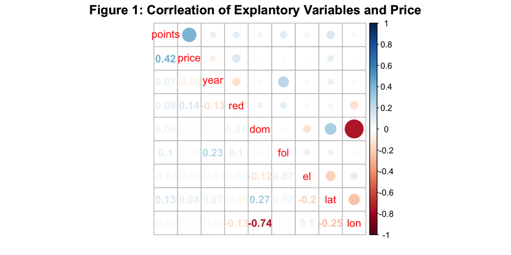

```r
# corrplot of primary variables
wine_reviews.df %>%
  select(points, price, year, red, dom, fol, el, lat, lon) %>%
  cor() %>% corrplot.mixed(title = "Figure 1: Corrleation of Explantory Variables and Price",
    mar = c(1,1,1.5,1))
```

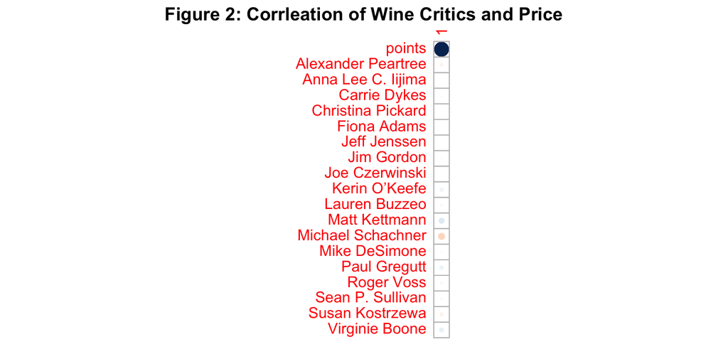

```r
# critic plot
wine_reviews.df %>%
  dplyr::select(points, contains("name")) %>%
  setNames(c("points", str_remove(str_subset(names(wine_reviews.df), "name"), "name"))) %>%
  cor(wine_reviews.df$points) %>% corrplot(title = "Figure 2: Corrleation of Wine Critics and Price",
    mar = c(1,1,1.5,1), cl.pos='n')
```

### Feature Selection

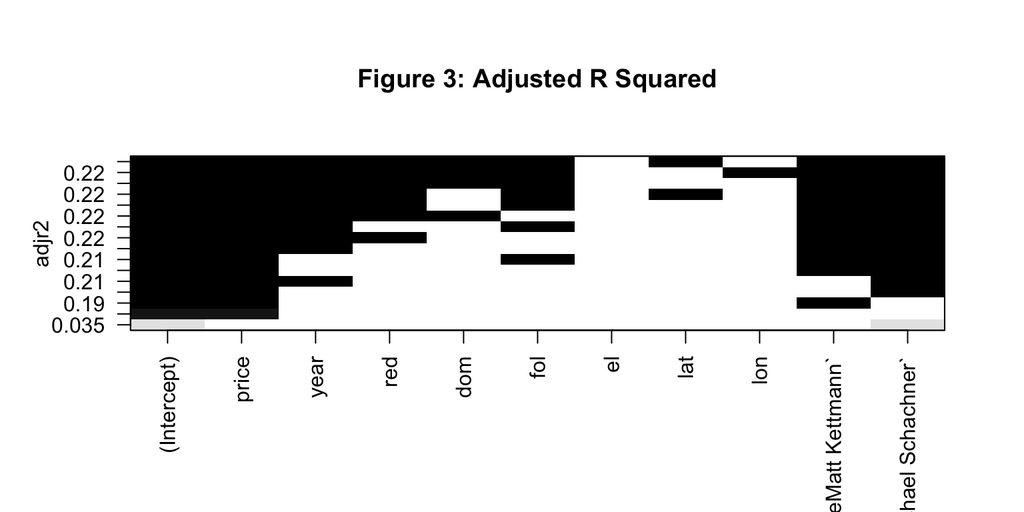

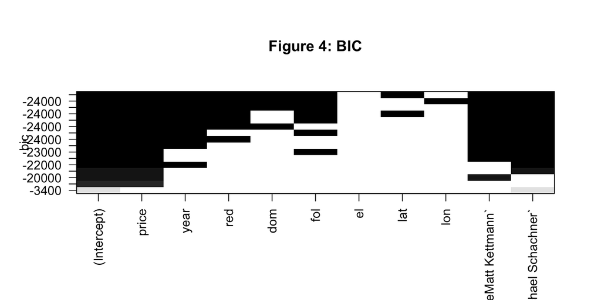

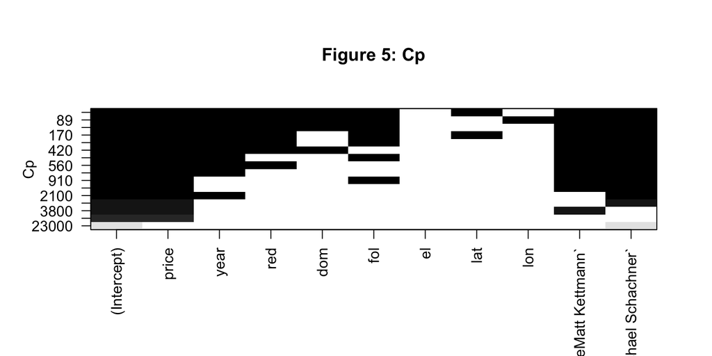

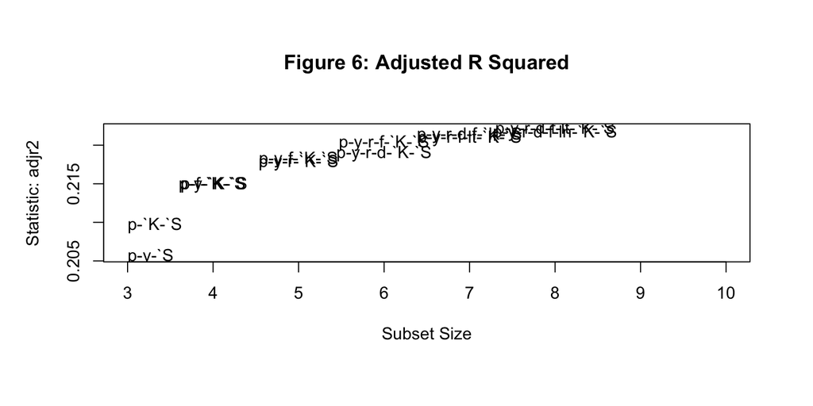

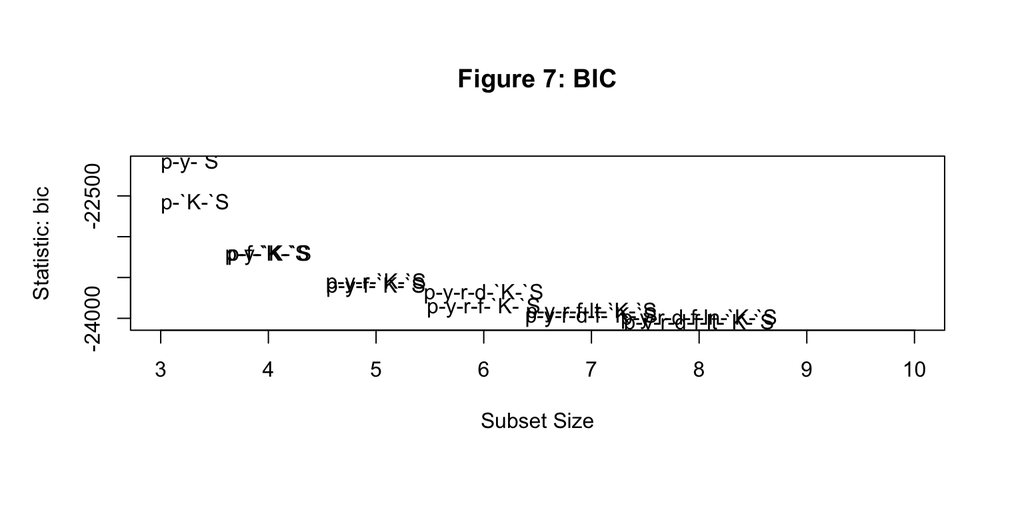

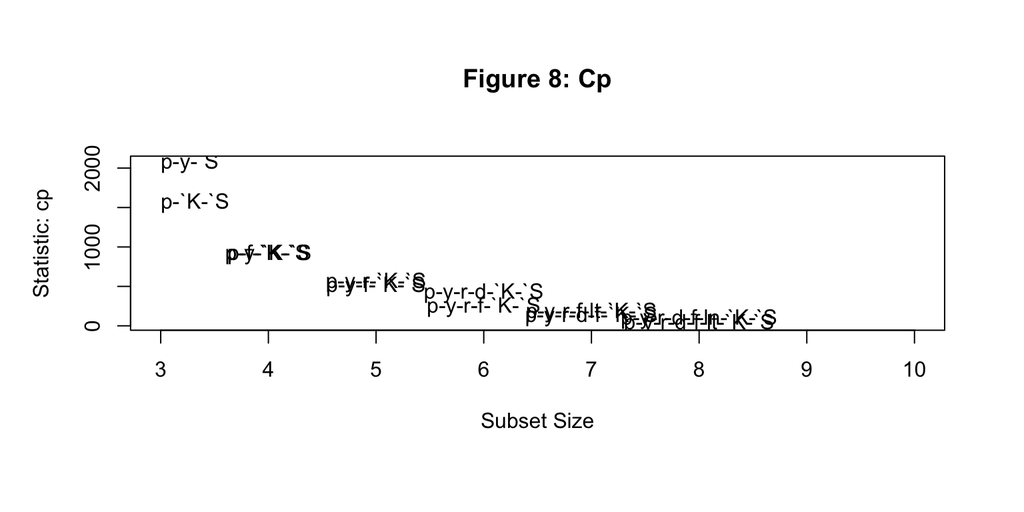

Table 2

|  | Estimate | Std. Error | t value | Pr(>\|t\|) |
| --- | --- | --- | --- | --- |
| (Intercept) | -26.13269 | 5.20366 | -5.02 | 0 |
| price | 0.02826 | 0.00021 | 137.44 | 0 |
| year | 0.05633 | 0.00259 | 21.76 | 0 |
| red | 0.33820 | 0.01923 | 17.58 | 0 |
| dom | -0.23989 | 0.01955 | -12.27 | 0 |
| fol | 0.00006 | 0.00000 | 17.35 | 0 |
| lat | 0.00442 | 0.00045 | 9.77 | 0 |
| `nameMatt Kettmann` | 1.39887 | 0.03911 | 35.77 | 0 |
| `nameMichael Schachner` | -1.21683 | 0.03342 | -36.41 | 0 |

### Lasso Regression

Although the stepwise regression revealed meaningful insights about the data, stepwise regression is often criticized for producing R-squared values that are badly biased to be high. Therefore, Data Wine’ing has chosen to supplement it’s feature selection analysis with a LASSO regression. Below we estimate a LASSO regression and perform parameter tuning on the data. Figure 9 displays the mean squared error as $\lambda$ increases and figure 10 dislplays the coefficients of the LASSO regression as $\lambda$ increaes. We find the model that minimized the mean squared error has a $\lambda$ of 0.001 and only sets the parameter of Anne.Krebiehl.MW equal to 0. In contrast the model which gives the most regularized model such that error is within one standard error of the minimum has as $\lambda$ of 0.0599 and sets the parameters of Anne.Krebiehl.MW, Carrie.Dykes, Christina.Pickard, Fiona.Adams, Jeff.Jenssen, Joe.Czerwinski, Kerin.O.Keef, Lauren.Buzzeo, Mike.DeSimone, Roger.Voss, Sean.P..Sullivan, lon and el equal to 0. We find that both model preform similar, explaining roughly $24\%$ and $23\%$ of the variation in the data respectively.

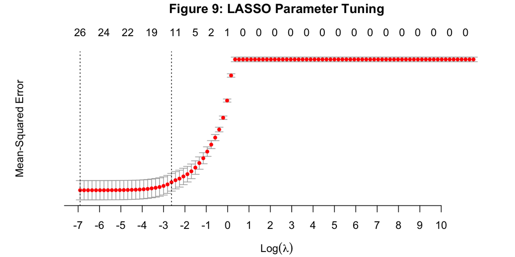

```r
# ----------------------------------------------------------------------------------
# prepare data
# ----------------------------------------------------------------------------------

# prepare data
wine_reviews.df <- raw_wine_reviews.df %>%
  mutate(
    red = ifelse(color == "red", 1, 0),
    dom = ifelse(country == "US", 1, 0)
  ) %>%
    rename(
    fol = taster_following, name = taster_name,
    lat = comp_lat, lon = comp_lon, el = comp_el
  ) %>%
   bind_cols(as_tibble(model.matrix(~name + 0, . ))) %>%
  select(points, price, year, red, dom, fol, el, lat, lon, contains("name"),
    -name, -`nameAnne Krebiehl MW`, -name1) %>%
  mutate_all(as.numeric) %>%
  filter_all(function(x){!is.na(x)})

# ------------------------------------------------------------------------------
# LASSO
# ------------------------------------------------------------------------------

# center y, X will be standardized in the modelling function
y <- wine_reviews.df %>% select(points) %>% scale(center = TRUE, scale = FALSE) %>% as.matrix()
X <- wine_reviews.df %>% select(-points) %>% as.matrix()

# 10 fold cross validation
lambdas_to_try <- 10^seq(-3, 5, length.out = 100)
lasso <- cv.glmnet(X, y, lambda = lambdas_to_try, standardize = TRUE, nfolds = 10)

# plot cross validation
par(mar = c(4,5,4,2))
plot(lasso, axes = F)
axis(side = 1, at = -10:10)
title("Figure 9: LASSO Parameter Tuning", line = 3)
```

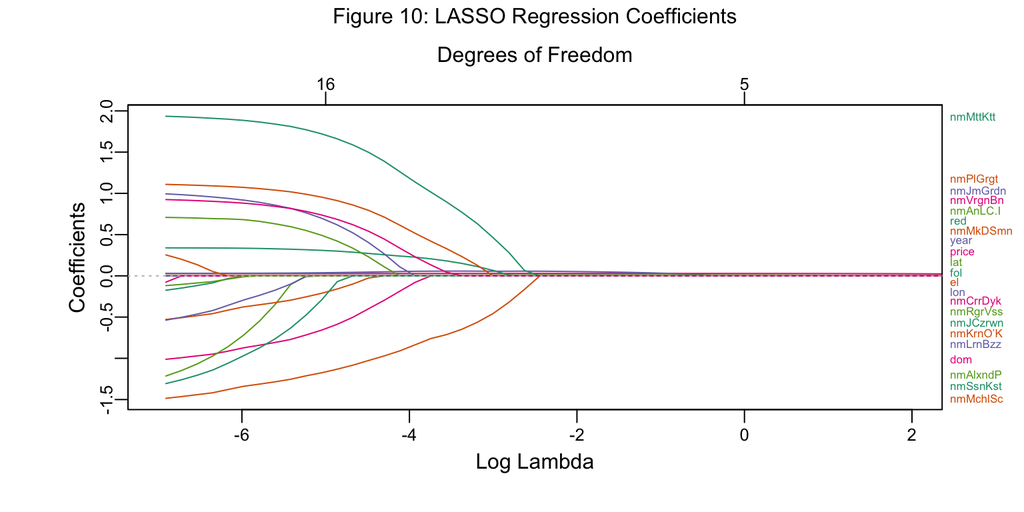

```r
# -----------------------------------------------------------------------------
# Test
# -----------------------------------------------------------------------------

# fit model that minimizes square residuals
lambda <- lasso$lambda.min
model <- glmnet(X, y, lambda = lambda, standardize = TRUE)
y_hat <- predict(model, X)
ssr <- t(y - y_hat) %*% (y - y_hat)
rsq_lasso_min <- cor(y, y_hat)^2
# model$beta

lambda <- lasso$lambda.1se
model <- glmnet(X, y, lambda = lambda, standardize = TRUE)
y_hat <- predict(model, X)
ssr <- t(y - y_hat) %*% (y - y_hat)
rsq_lasso_1se <- cor(y, y_hat)^2
# model$beta

# ---------------------------------------------------------------------------
# plot
# ---------------------------------------------------------------------------

res <- glmnet(X, y, alpha = 1, lambda = lambdas_to_try, standardize = FALSE)
plot_glmnet(res, xvar = "lambda", label = T, xlim= c(-7, 2), col = brewer.pal(5, "Dark2"), main = "Figure 10: LASSO Regression Coefficients")
```

```r
# rm(X, y, lambda, y_hat, ssr, model, res)
```

### Logistic Regressions

Recall that we are interested in informing wine consumers what the best predictors are for selecting a quality wine, whether they’re buying at their local wine store, or tasting wine at their favorite farmers market, we’d like to determine a metric for what really does constitute a “good” wine. In this section we aim to construct a logistic model that is capable of predicting whether a bottle of wine is above 88 points. The output variable of this logistic model will be `p88`, which is equal to 1 if a bottle has a score of above 88 points and 0 otherwise. An 88 point cutoff was selected as it nearly slices the dataset in half and makes for good use in model training and testing, including the fact that this score represents the delineation for what is “very good” and “excellent” wines and is just above the average score for all wine enthusiast reviews (Wine Enthusiast Magazine and Website, 2019). The model `glm(formula = p88 ~ . -points, data = wine_reviews.df, family = binomial(link="logit"))` was run to estimate `p88` and the output can be found in the table below (table 3).

```r
# -----------------------------------------------------------------------------
# read in data
# -----------------------------------------------------------------------------

# Read in data
wine_reviews.df <-  raw_wine_reviews.df %>%
  mutate(
    red = as.factor(ifelse(color == "red", 1, 0)),
    dom = as.factor(ifelse(country == "US", 1, 0)),
    p88 = ifelse(points > 88, 1, 0)
  ) %>%
  dplyr::select(
    points, price, year, red, dom, taster_following, comp_el, comp_lat, comp_lon, p88, taster_name
  ) %>%
  rename(
    fol = taster_following, name = taster_name,
    lat = comp_lat, lon = comp_lon, el = comp_el
  ) %>%
  filter_all(function(x){!is.na(x)})

# -----------------------------------------------------------------------------
# estimate and evaluate model
# -----------------------------------------------------------------------------

# Estimate model
glm <- glm(formula = p88 ~ . -points, data = wine_reviews.df, family = binomial(link = "logit"))
# exp(coef(glm))
xkabledply(glm, title = "Table 3: Logistic Regression")
```

Table 3: Logistic Regression

|  | Estimate | Std. Error | z value | Pr(>\|z\|) |
| --- | --- | --- | --- | --- |
| (Intercept) | -56.1556 | 5.3114 | -10.57 | 0.0000 |
| price | 0.0619 | 0.0005 | 114.62 | 0.0000 |
| year | 0.0269 | 0.0026 | 10.19 | 0.0000 |
| red1 | -0.1212 | 0.0172 | -7.07 | 0.0000 |
| dom1 | -0.7404 | 0.0379 | -19.53 | 0.0000 |
| fol | 0.0002 | 0.0000 | 15.31 | 0.0000 |
| el | 0.0000 | 0.0000 | 2.20 | 0.0276 |
| lat | -0.0006 | 0.0005 | -1.23 | 0.2205 |
| lon | -0.0004 | 0.0002 | -2.03 | 0.0420 |
| nameAlexander Peartree | -1.8565 | 0.2444 | -7.60 | 0.0000 |
| nameAnna Lee C. Iijima | 0.7451 | 0.0437 | 17.04 | 0.0000 |
| nameCarrie Dykes | -1.2070 | 0.3057 | -3.95 | 0.0001 |
| nameChristina Pickard | -1.2906 | 1.3043 | -0.99 | 0.3224 |
| nameFiona Adams | -1.5843 | 0.7280 | -2.18 | 0.0295 |
| nameJeff Jenssen | 0.3729 | 0.1372 | 2.72 | 0.0066 |
| nameJim Gordon | 1.0068 | 0.0408 | 24.66 | 0.0000 |
| nameJoe Czerwinski | -0.6267 | 0.0840 | -7.46 | 0.0000 |
| nameKerin O’Keefe | -1.6268 | 0.0948 | -17.16 | 0.0000 |
| nameLauren Buzzeo | -0.4133 | 0.0753 | -5.48 | 0.0000 |
| nameMatt Kettmann | 0.7673 | 0.0419 | 18.29 | 0.0000 |
| nameMichael Schachner | -0.6959 | 0.0453 | -15.35 | 0.0000 |
| nameMike DeSimone | 0.7753 | 0.1493 | 5.19 | 0.0000 |
| namePaul Gregutt | 0.3995 | 0.0448 | 8.91 | 0.0000 |
| nameRoger Voss | -0.0798 | 0.0373 | -2.14 | 0.0323 |
| nameSean P. Sullivan | -1.5593 | 0.1392 | -11.20 | 0.0000 |
| nameSusan Kostrzewa | -1.2475 | 0.1204 | -10.36 | 0.0000 |

```r
# Accuracy
cm <- regclass::confusion_matrix(glm)
accuracy_glm <- (cm[1,1]+cm[2,2])/(cm[1,1] + cm[1,2] + cm[2,1] + cm[2,2])*100
cm %>% kable(caption = "Table 4: Confusion Matrix of Logistic Regression") %>% kable_styling()
```

Table 4: Confusion Matrix of Logistic Regression

|  | Predicted 0 | Predicted 1 | Total |
| --- | --- | --- | --- |
| Actual 0 | 40864 | 9168 | 50032 |
| Actual 1 | 16300 | 29869 | 46169 |
| Total | 57164 | 39037 | 96201 |

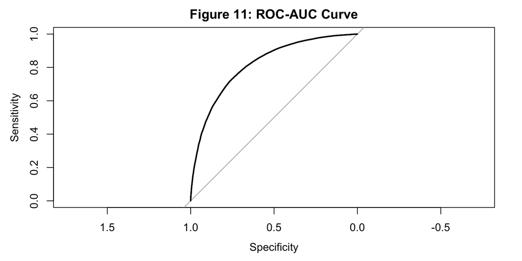

```r
# ROC-AUC
wine_reviews.df$prob <- predict(glm, type=c("response"))
roc <- pROC::roc(p88 ~ prob, data=wine_reviews.df)
plot(roc, main = "Figure 11: ROC-AUC Curve")
```

```r
# Scale dataset
wine_reviews_z <- uzscale(wine_reviews.df, append=0, excl=c("p88"))

# Sample and subset
wine_reviews_sample <- sample(2, nrow(wine_reviews_z), replace = TRUE, prob = c(0.75, 0.25))
wine_reviews_train <- filter(wine_reviews_z, wine_reviews_sample == 1)
wine_reviews_test <- filter(wine_reviews_z, wine_reviews_sample == 2)

# Estimate logistic model using training data
wine_reviews_logit <- glm(p88 ~ . -points, data = wine_reviews_train, family = binomial)
# summary(wine_reviews_logit)

wine_reviews_logit$xlevels[["taster_name"]] <- union(wine_reviews_logit$xlevels[["taster_name"]], levels(wine_reviews_test$taster_name))

# Use cutoff rule to classify type
wine_reviews_test <- wine_reviews_test %>%
  mutate(
    p88_logit_p = predict(wine_reviews_logit, wine_reviews_test, type = c("response")),
    p88_logit = ifelse(p88_logit_p > 0.5, 1, 0)
  )

# Calculate accuracy
t <- table(wine_reviews_test$p88, wine_reviews_test$p88_logit)
# (t[1,1] + t[2,2]) / nrow(wine_reviews_test)

# Clean up
rm(wine_reviews_z, wine_reviews_sample, wine_reviews_train, wine_reviews_test, wine_reviews_logit, t)
```

### K Nearst Neighbor

```r
# -----------------------------------------------------------------------------
# Prepare data
# -----------------------------------------------------------------------------

# wrangle data
wine2 <- raw_wine_reviews.df %>%
  dplyr::mutate(
    red = ifelse(color == "red", 1, 0),
    dom = ifelse(country == "US", 1, 0),
    p88 = ifelse(points > 88, 1, 0)
  ) %>%
  dplyr::select(
    p88, price, year, red, dom, taster_following, taster_name,
    comp_lon, comp_lat, comp_el, p88
  ) %>%
  rename(
    fol = taster_following, name = taster_name,
    lat = comp_lat, lon = comp_lon, el = comp_el
  ) %>%
  filter_all(function(x) !is.na(x))

# -----------------------------------------------------------------------------
# Create partition
# -----------------------------------------------------------------------------

wine2 <- wine2 %>% dplyr::select(-p88, everything())
wine2 <- wine2 %>% dplyr::select(-name, everything())
scaled_wine2 <- as.data.frame(scale(wine2[1:8], center = TRUE, scale = TRUE))

wine2_sample <- sample(2, nrow(scaled_wine2), replace=TRUE, prob=c(0.75, 0.25))

# subset
wine2_training <- scaled_wine2[wine2_sample==1, 1:8]
wine2_test <- scaled_wine2[wine2_sample==2, 1:8]

# labels
wine2.trainLabels <- wine2[wine2_sample==1, 9]
wine2.testLabels <- wine2[wine2_sample==2, 9]

# -----------------------------------------------------------------------------
# Find best K
# -----------------------------------------------------------------------------

# create an empty dataframe to store the results from confusion matrices
cmdf = data.frame()

for (kval in 3:15) {
  # predict
  wine2_pred <- knn(train = wine2_training, test = wine2_test, cl = wine2.trainLabels, k = kval)
  cm <- confusionMatrix(wine2_pred, reference = factor(wine2.testLabels ))
  # construct table
  accuracy <- cm$overall['Accuracy']
  cmt <- data.frame(K = kval, Accuracy = accuracy, row.names = NULL ) # initialize a row of the metrics
  cmt <- cbind(cmt, data.frame(t(cm$byClass))) # the dataframe of the transpose, with k valued added in front
  cmdf = rbind(cmdf, cmt)
}

# print table
cmdf %>%
  dplyr::select(K, Accuracy, Precision, Recall, Sensitivity, F1) %>%
  xkabledply(title = "Table 5: Summary Statistics of kNN Classification")
```

Table 5: Summary Statistics of kNN Classification

| K | Accuracy | Precision | Recall | Sensitivity | F1 |
| --- | --- | --- | --- | --- | --- |
| 3 | 0.727 | 0.737 | 0.743 | 0.743 | 0.740 |
| 4 | 0.724 | 0.700 | 0.830 | 0.830 | 0.759 |
| 5 | 0.732 | 0.743 | 0.749 | 0.749 | 0.746 |
| 6 | 0.731 | 0.716 | 0.809 | 0.809 | 0.759 |
| 7 | 0.737 | 0.749 | 0.748 | 0.748 | 0.749 |
| 8 | 0.735 | 0.724 | 0.798 | 0.798 | 0.759 |
| 9 | 0.738 | 0.751 | 0.748 | 0.748 | 0.749 |
| 10 | 0.738 | 0.730 | 0.793 | 0.793 | 0.760 |
| 11 | 0.740 | 0.751 | 0.753 | 0.753 | 0.752 |
| 12 | 0.740 | 0.733 | 0.793 | 0.793 | 0.762 |
| 13 | 0.741 | 0.750 | 0.757 | 0.757 | 0.754 |
| 14 | 0.740 | 0.735 | 0.788 | 0.788 | 0.761 |
| 15 | 0.740 | 0.749 | 0.756 | 0.756 | 0.753 |

### K Means

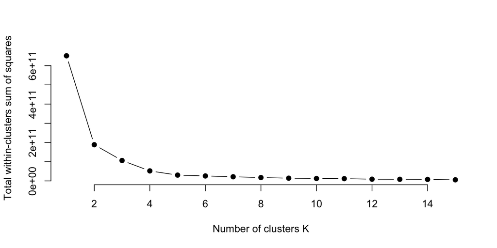

```r
# -----------------------------------------------------------------------------
# Prepare data
# -----------------------------------------------------------------------------

winedata <- raw_wine_reviews.df
wine <- winedata %>%
 dplyr::mutate(
    red = ifelse(color == "red", 1, 0),
    dom = ifelse(country == "US", 1, 0)
  ) %>%
 dplyr::select(points, price, year, taster_following, comp_el, comp_lat, comp_lon) %>%
 mutate_all(as.numeric) %>%
 rename(
    fol = taster_following,
    lat = comp_lat, lon = comp_lon, el = comp_el
  ) %>%
 filter_all(function(x){!is.na(x)})

# Remove Outliers
outliers <- boxplot(wine$price, plot=FALSE)$out
wine2<- wine[-which(wine$price %in% outliers),]

# -----------------------------------------------------------------------------
# K Means
#   Analysis inspired by https://uc-r.github.io/kmeans_clustering
# ---------------------------------------------------------------------------

# function to compute total within-cluster sum of square
wss <- function(k) {
  kmeans(wine2, k, nstart = 10 )$tot.withinss
}

# Compute and plot wss for k = 1 to k = 15
k.values <- 1:15

# extract wss for 2-15 clusters
wss_values <- map_dbl(k.values, wss)

plot(k.values, wss_values,
  type = "b", pch = 19, frame = FALSE,
  xlab = "Number of clusters K",
  ylab = "Total within-clusters sum of squares"
)
```

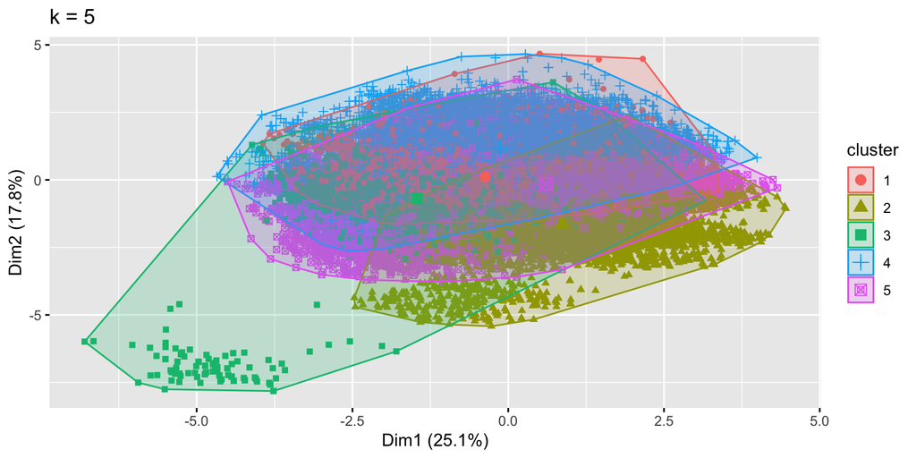

```r
# n start is just the number of configurations, we dont really need that
k <- kmeans(wine2, centers = 5)
# print(k)

# Plots to compare
fviz_cluster(k, geom = "point",  data = wine2) + ggtitle("k = 5")
```

```r
# Cluster Mean
# k$centers
# Number of values in each cluster
# k$size

# ---------------------------------------------------------------------------
# Summary statistics of clusters
# ---------------------------------------------------------------------------

# mean
wine2 %>%
  mutate(Cluster = k$cluster) %>%
  group_by(Cluster) %>%
  summarize_all("mean") %>%
  kable() %>% kable_styling()
```

| Cluster | points | price | year | fol | el | lat | lon |
| --- | --- | --- | --- | --- | --- | --- | --- |
| 1 | 87.9 | 24.2 | 2012 | 1159.898 | 171 | 32.99 | -41.4 |
| 2 | 88.7 | 32.8 | 2012 | 7643.451 | 366 | 43.48 | -63.0 |
| 3 | 87.0 | 22.1 | 2010 | 1492.378 | 886 | 7.19 | -29.5 |
| 4 | 87.7 | 30.6 | 2008 | 0.665 | 211 | 38.39 | -80.2 |
| 5 | 89.1 | 33.9 | 2011 | 2998.433 | 247 | 34.76 | -91.5 |

```r
# median
wine2 %>%
  mutate(Cluster = k$cluster) %>%
  group_by(Cluster) %>%
  summarize_all("median") %>%
  kable() %>% kable_styling()
```

| Cluster | points | price | year | fol | el | lat | lon |
| --- | --- | --- | --- | --- | --- | --- | --- |
| 1 | 88 | 20 | 2012 | 1047 | 145 | 41.0 | -8.22 |
| 2 | 88 | 29 | 2012 | 6283 | 239 | 45.4 | -89.53 |
| 3 | 87 | 18 | 2011 | 1451 | 769 | 38.5 | -3.75 |
| 4 | 87 | 26 | 2009 | 0 | 145 | 38.5 | -119.42 |
| 5 | 89 | 30 | 2012 | 2565 | 158 | 38.5 | -120.66 |